# Lab 2: Cats vs Dogs

### Part (f) - 5pt

How does the your best CNN model compare with an 2-layer ANN model (no convolutional layers) on classifying cat and dog images. You can use a 2-layer ANN architecture similar to what you used in Lab 1. You should explore different hyperparameter settings to determine how well you can do on the validation dataset. Once satisified with the performance, you may test it out on the test data.

Hint: The ANN in lab 1 was applied on greyscale images. The cat and dog images are colour (RGB) and so you will need to flatted and concatinate all three colour layers before feeding them into an ANN.

```
Files already downloaded and verified
Files already downloaded and verified
Files already downloaded and verified
Files already downloaded and verified
Epoch 1: Train err: 0.42825, Train loss: 0.6769170872867107 |Validation err: 0.399, Validation loss: 0.6595642492175102
Epoch 2: Train err: 0.38925, Train loss: 0.6519035808742046 |Validation err: 0.387, Validation loss: 0.6519387736916542
Epoch 3: Train err: 0.374875, Train loss: 0.640537403523922 |Validation err: 0.384, Validation loss: 0.6483716294169426
Epoch 4: Train err: 0.362875, Train loss: 0.6315739527344704 |Validation err: 0.3905, Validation loss: 0.6505655869841576
Epoch 5: Train err: 0.35725, Train loss: 0.6245692558586597 |Validation err: 0.376, Validation loss: 0.6418333128094673
Epoch 6: Train err: 0.340875, Train loss: 0.6168352533131838 |Validation err: 0.3745, Validation loss: 0.6437233984470367
Epoch 7: Train err: 0.33225, Train loss: 0.6098569743335247 |Validation err: 0.372, Validation loss: 0.6399524658918381
Epoch 8: Train err: 0.3235, Train loss: 0.6023368798196316 |Validation err: 0.37, Validation loss: 0.6408602595329285
Epoch 9: Train err: 0.31675, Train loss: 0.5958488956093788 |Validation err: 0.379, Validation loss: 0.6431653872132301
Epoch 10: Train err: 0.308875, Train loss: 0.5869064759463072 |Validation err: 0.3675, Validation loss: 0.641803428530693
Epoch 11: Train err: 0.305625, Train loss: 0.5777441300451756 |Validation err: 0.3655, Validation loss: 0.6427131667733192
Epoch 12: Train err: 0.290625, Train loss: 0.5667552649974823 |Validation err: 0.358, Validation loss: 0.6428103223443031
Epoch 13: Train err: 0.287625, Train loss: 0.5631313007324934 |Validation err: 0.366, Validation loss: 0.6496094092726707
Epoch 14: Train err: 0.2765, Train loss: 0.5500430027022958 |Validation err: 0.363, Validation loss: 0.643232561647892
Epoch 15: Train err: 0.265625, Train loss: 0.5386046478524804 |Validation err: 0.3605, Validation loss: 0.6481608599424362
Epoch 16: Train err: 0.26175, Train loss: 0.531502615660429 |Validation err: 0.369, Validation loss: 0.6510078310966492
Epoch 17: Train err: 0.252125, Train loss: 0.5224597165361047 |Validation err: 0.357, Validation loss: 0.6472270339727402
Epoch 18: Train err: 0.247125, Train loss: 0.5170230884104967 |Validation err: 0.359, Validation loss: 0.6442254483699799
Epoch 19: Train err: 0.238125, Train loss: 0.5016351230442524 |Validation err: 0.368, Validation loss: 0.6731988787651062
Epoch 20: Train err: 0.234, Train loss: 0.49260974396020174 |Validation err: 0.3605, Validation loss: 0.6575946733355522
Epoch 21: Train err: 0.224375, Train loss: 0.4835393028333783 |Validation err: 0.364, Validation loss: 0.6698974892497063
Epoch 22: Train err: 0.220375, Train loss: 0.47741825971752405 |Validation err: 0.3665, Validation loss: 0.6688803806900978
Epoch 23: Train err: 0.21525, Train loss: 0.4649003678932786 |Validation err: 0.369, Validation loss: 0.6795682236552238
Epoch 24: Train err: 0.2005, Train loss: 0.4509896459057927 |Validation err: 0.3695, Validation loss: 0.6841867566108704
Epoch 25: Train err: 0.202875, Train loss: 0.44514959678053856 |Validation err: 0.3605, Validation loss: 0.673137292265892
Epoch 26: Train err: 0.19325, Train loss: 0.43599317874759436 |Validation err: 0.3685, Validation loss: 0.7121472507715225
Epoch 27: Train err: 0.19575, Train loss: 0.4321617428213358 |Validation err: 0.3705, Validation loss: 0.6955582797527313
Epoch 28: Train err: 0.17525, Train loss: 0.4115605400875211 |Validation err: 0.359, Validation loss: 0.7012656480073929
Epoch 29: Train err: 0.177, Train loss: 0.4048158936202526 |Validation err: 0.396, Validation loss: 0.801465816795826
Epoch 30: Train err: 0.17275, Train loss: 0.40256923995912075 |Validation err: 0.3535, Validation loss: 0.703335627913475
Finished Training
Total time elapsed: 767.92 seconds
```

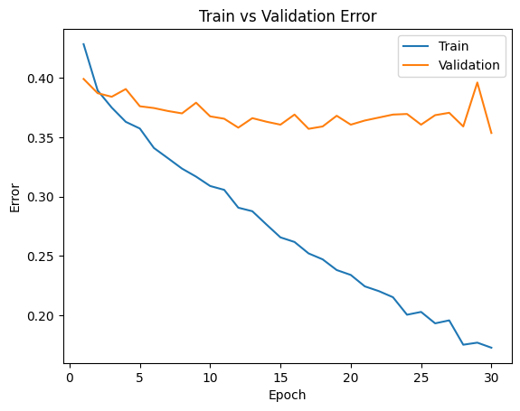

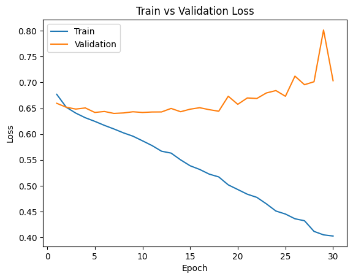

[output not shown]

```python
torch.manual_seed(1)
#Adapt the ANN for RGB colours
class RGBPigeon(nn.Module):
    def __init__(self, hidden_units):
        super(RGBPigeon, self).__init__()
        self.layer1 = nn.Linear(32*32*3, hidden_units)
        self.layer2 = nn.Linear(hidden_units, 1)
        self.name = "RGBPigeon"

    def forward(self, img):
        flattened = img.view(-1, 32*32*3)
        activation1 = self.layer1(flattened)
        activation1 = F.relu(activation1)
        activation2 = self.layer2(activation1)
        activation2 = activation2.squeeze(1)
        return activation2

train_loader, val_loader, test_loader, classes = get_data_loader(
    target_classes=["cat", "dog"],
    batch_size=64
)

hidden_units = 50
learning_rate = 0.01
batch_size = 256
num_epochs = 30

'''Note: the best hyperparameter I found was the third tuning (see below) but
for the comparison's sake I sticked to the same tuning values as CNN's.'''

ann_net = RGBPigeon(hidden_units)
train_net(ann_net, batch_size, learning_rate, num_epochs)

model_name = get_model_name(ann_net.name, batch_size, learning_rate, num_epochs-1)

best_state = torch.load(model_name)
ann_net.load_state_dict(best_state)


plot_training_curve(model_name)


'''
First tuning:
- hidden units: 50
- learning rate: 0.01
- batch_size: 128
_ epochs: 30
--> validation error (lowest): 0.375
--> time elapsed: 767.37s
--> huge gap between train and validation e/l graphs --> lower learning rate
--> validation loss graph does not decrease

Second tuning:
- hidden units: 50
- learning rate: 0.001
- batch_size: 128
_ epochs: 30
--> validation error: 0.387
--> time elapsed: 734.88s
--> smaller gap
--> validation loss graph decreases before plateauing in the end
--> increase batch size

Third tuning:
- hidden units: 50
- learning rate: 0.001
- batch_size: 256
_ epochs: 30
--> validation error: 0.3745
--> time elapsed: 769.85
--> smallest gap
--> validation loss graph mostly decreases
--> choose this hyperparameter

However to compare with CNN's hyperparameter we'll stick to:
- hidden units: 50
- learning rate: 0.01
- batch_size: 256
_ epochs: 30
'''
```

```python
train_loader, val_loader, test_loader, classes = get_data_loader(
    target_classes=["cat", "dog"],
    batch_size=64)

net = RGBPigeon(hidden_units)
best_model_path = "model_RGBPigeon_bs256_lr0.01_epoch29" #0.3535
net.load_state_dict(torch.load(best_model_path))
net.eval()

criterion = nn.BCEWithLogitsLoss()
test_err, test_loss = evaluate(net, test_loader, criterion)

print("Test Classification Error: {:.4f}".format(test_err))

'''
Test error for my best CNN model is lower than the test error for ANN in lab 1,
with 0.3180 compared to 0.3570, suggesting that the CNN model is better suited
for the task classifying cat and dog images. This difference could be due to
the CNN's ability to learn spatial hierarchies of features, compared to more
limited capability of the ANN to capture such complex patterns.
'''
```

```
Files already downloaded and verified
Files already downloaded and verified
Test Classification Error: 0.3570
```

[output not shown]